# distributions_20190930_oh

# 5. Visualizing data distributions

보통 numerical data 두가지로 summarize됨

1.the *average* value.  
2. the *standard deviation* aka *SD*.

ex) you might read a report stating that scores were 680 plus or minus 50 (the *standard deviation*).

Is this appropriate? Is there any important piece of information that we are missing by only looking at this summary rather than the entire list?

**–>> 그래서!! data visualization building block의 첫 순서는 lists of factors or numeric vectors을 요약하는것임, 즉 필요한 정보만 쏙쏙 빼먹는 것**

The most basic statistical summary of a list of objects or numbers is its distribution. Once a vector has been summarized as a distribution, there are several data visualization techniques to effectively relay this information.

In this chapter, 1. discuss properties of a variety of distributions 2. how to visualize distributions using a motivating example of student heights. 3. discuss the **ggplot2** geometries for these visualizations in Section @ref(other-geometries).

## 5.1 Variable types

We will be working with two types of variables:

| **categorical**: vector가 group으로 나뉘어짐 | **numeric**: 말그대로 그냥 숫자 데이터 |
| --- | --- |
| **1. ordinal:순서**: spiciness (mild, medium, hot) | **1. continuous**: (if measured with enough precision) heights |
| **2. Not ordinal**: sex (male or female), regions (South, West) | **2. discrete**: (round number)population sizes, murder rates, |

Keep in mind!! 1. discrete numeric data는 considered ordinal가 될 수 있음.

Although this is technically true, we usually reserve the term ordinal data for variables belonging to a small number of different groups, with each group having many members.

In contrast, when we have many groups with few cases in each group, we typically refer to them as discrete numerical variables.

ex) the number of packs of cigarettes a person smokes a day, rounded to the closest pack, would be considered ordinal,

while the actual number of cigarettes would be considered a numerical variable. But, indeed, there are examples that can be considered both numerical and ordinal when it comes to visualizing data.

## 5.2 Case study: describing student heights

Here we introduce a new motivating problem. It is an artificial one, but it will help us illustrate the concepts needed to understand distributions.

Pretend that we have to describe the heights of our classmates to ET, an extraterrestrial that has never seen humans. As a first step, we need to collect data. To do this, we ask students to report their heights in inches. We ask them to provide sex information because we know there are two different distributions by sex. We collect the data and save it in the `heights` data frame:

```r
library(tidyverse)
library(dslabs)
data(heights)
```

One way to convey the heights to ET is to simply send him this list of `nrow(heights)` heights. But there are much more effective ways to convey this information, and understanding the concept of a distribution will help. To simplify the explanation, we first focus on male heights. We examine the female height data in Section @ref(student-height-cont).

## 5.3 Distribution function: 분포 함수 for 카테고리별 수치 비교 by simple barplot

*average* 와 *standard deviation: SD***만으로** 써머리 해도 ㄱㅊ할때 –>> **distribution function visualization**사용!

1. The most basic statistical summary of a list of objects or numbers  
2. a compact description of a list with many entries.

ex) with categorical data, the distribution simply describes the proportion of each unique category. The sex represented in the heights dataset is:

```
##
## Female   Male
##    238    812
```

```
##
##    Female      Male
## 0.2266667 0.7733333
```

```
## [1] 0.2266667
```

```
## [1] 23
```

위에처럼 두개 카테고리만 있으면 비교가 쉬우니 ㄱㅊ함.. 굳이 visualize할 필요X since one number describes everything we need to know: 23% are females and the rest are males.

**When there are more categories, then a simple barplot describes the distribution.** Here is an example with US state regions:

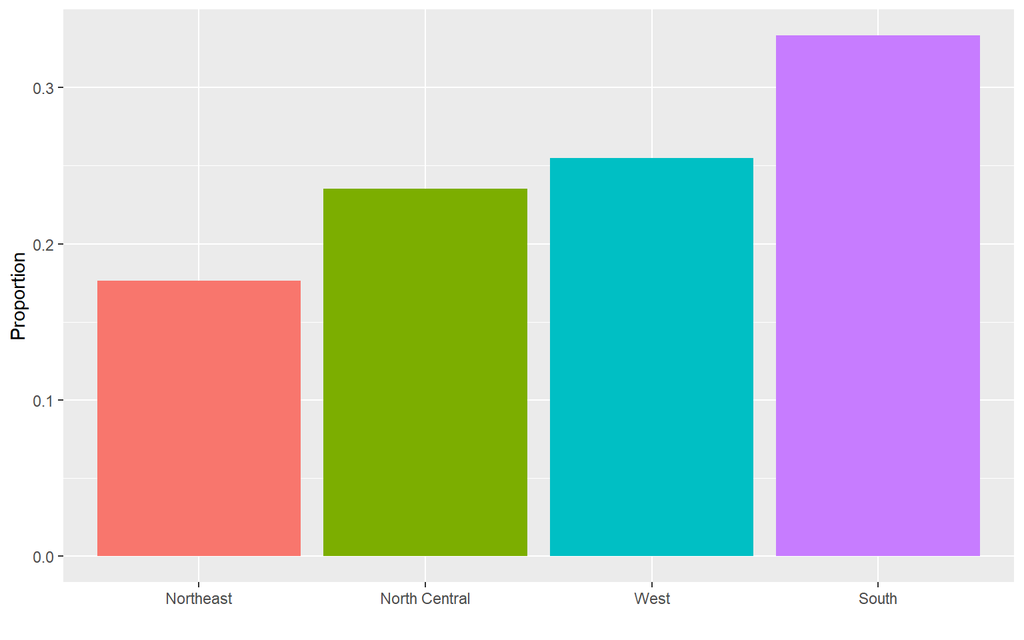

This particular plot simply shows us four numbers, one for each category. We usually use barplots to display a few numbers. Although this particular plot does not provide much more insight than a frequency table itself, it is a first example of how we convert a vector into a plot that succinctly summarizes all the information in the vector. When the data is numerical, the task of displaying distributions is more challenging.

## 5.4 Cumulative distribution functions {#cdf-intro} aka CDF for 시퀀스별 누적 (empirical)

catogrical이 아닌 Numerical data는 또한 distribution가짐. –>> 대다수 entries가 unique한 경우임. 일치되는 데이터가 아닌.

ex) In our case study, while several students reported a height of 68 inches, only one student reported a height of `68.503937007874` inches and only one student reported a height `68.8976377952756` inches. We assume that they converted from 174 and 175 centimeters, respectively.

통계책 보면..distribution for numeric data를 useful한 function으로 define하고 있는데.. 이 function이 바로 **cumulative distribution function aka CDF**

$$F(a) = \mbox{Pr}(x \leq a)$$

Here is a plot of $F$ for the male height data:

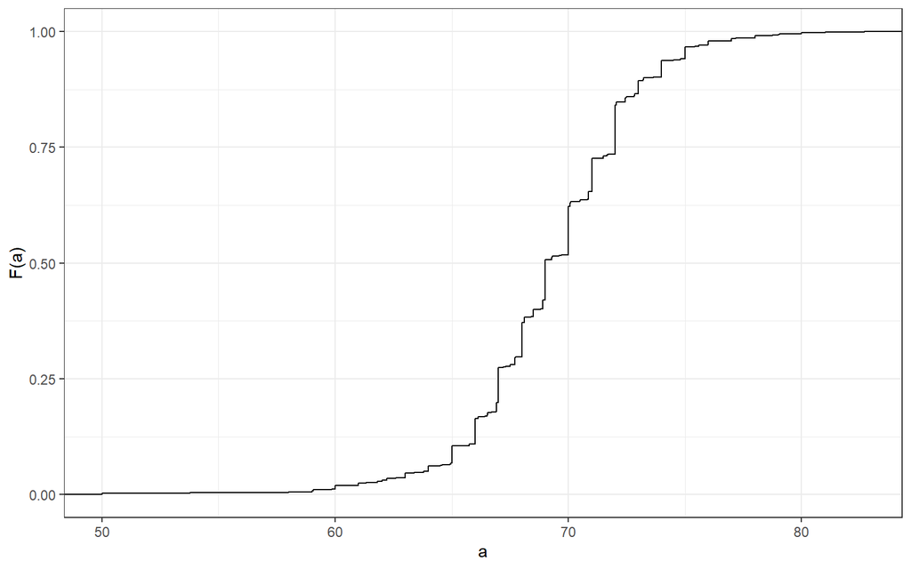

the frequency table이 categorical data를 위한 것 처럼  
the CDF defines the distribution for numerical data.

In fact, we can report the proportion of values between any two heights, say $a$ and $b$, by computing $F(b) - F(a)$. This means that if we send this plot above to ET, he will have all the information needed to reconstruct the entire list. Paraphrasing the expression “a picture is worth a thousand words”, in this case, a picture is as informative as 812 numbers.

A final note: because CDFs can be defined mathematically the word *empirical* is added to make the distinction when data is used. We therefore use the term empirical CDF (eCDF).

Although the CDF concept is widely discussed in statistics textbooks, the plot is actually not very popular in practice. It does not convey characteristics of interest such as..

<<– 1. At what value is the distribution centered?  
2. Is the distribution symmetric?  
3. What ranges contain 95% of the values?

## 5.5 Histograms: 도수 분포 정보그림

So, Histograms are much preferred because they greatly facilitate answering such questions. 히스토그램은 몇몇 경향성에서 튀는 데이터를 sacrifice해서 interpret를 쉽게 해줌

The simplest way to make a histogram is to divide the span of our data into non-overlapping bins of the same size.  
Then, for each bin, we count the number of values that fall in that interval. The histogram plots these counts as bars with the base of the bar defined by the intervals. Here is the histogram for the height data splitting the range of values into one inch intervals: $[49.5, 50.5], [51.5,52.5],(53.5,54.5],...,(82.5,83.5]$

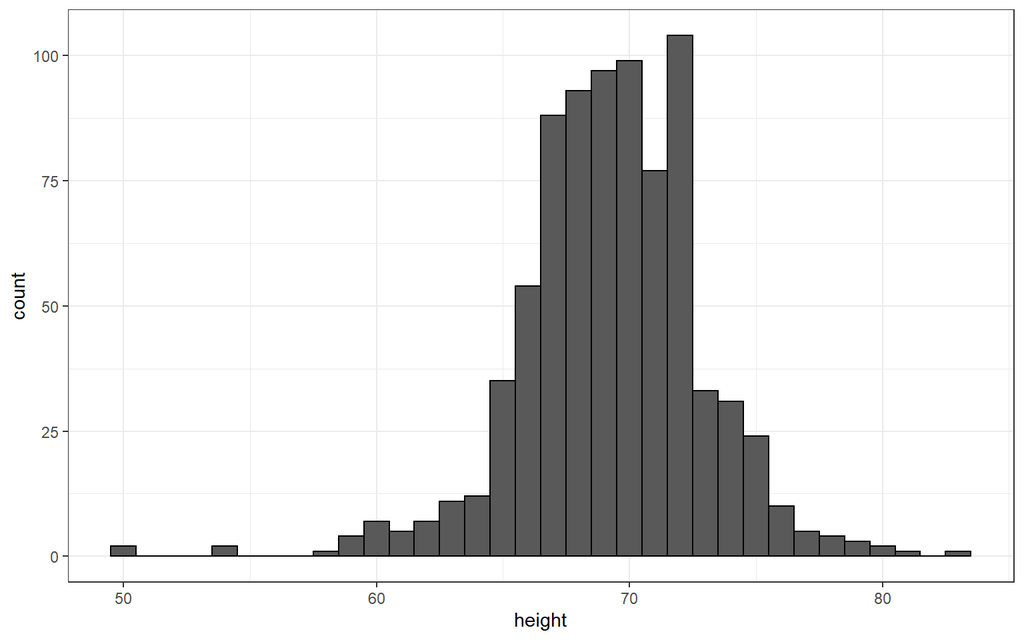

As you can see in the figure above, a histogram is similar to a barplot, but it differs in that the x-axis is numerical, not categorical.

If we send this plot to ET, he will immediately learn some important properties about our data. First, the range of the data is from 50 to 84 with the majority (more than 95%) between 63 and 75 inches. Second, the heights are close to symmetric around 69 inches. Also, by adding up counts, ET could obtain a very good approximation of the proportion of the data in any interval. Therefore, the histogram above is not only easy to interpret, but also provides almost all the information contained in the raw list of 812 heights with about 30 bin counts.

What information do we lose? Note that all values in each interval are treated the same when computing bin heights. So, for example, the histogram does not distinguish between 64, 64.1, and 64.2 inches. Given that these differences are almost unnoticeable to the eye, the practical implications are negligible and we were able to summarize the data to just 23 numbers.

We discuss how to code histograms in Section @ref(other-geometries).

## 5.6 Smoothed density: 도수분포표 의 적분

Smooth density plots are aesthetically more appealing than histograms. Here is what a smooth density plot looks like for our heights data:

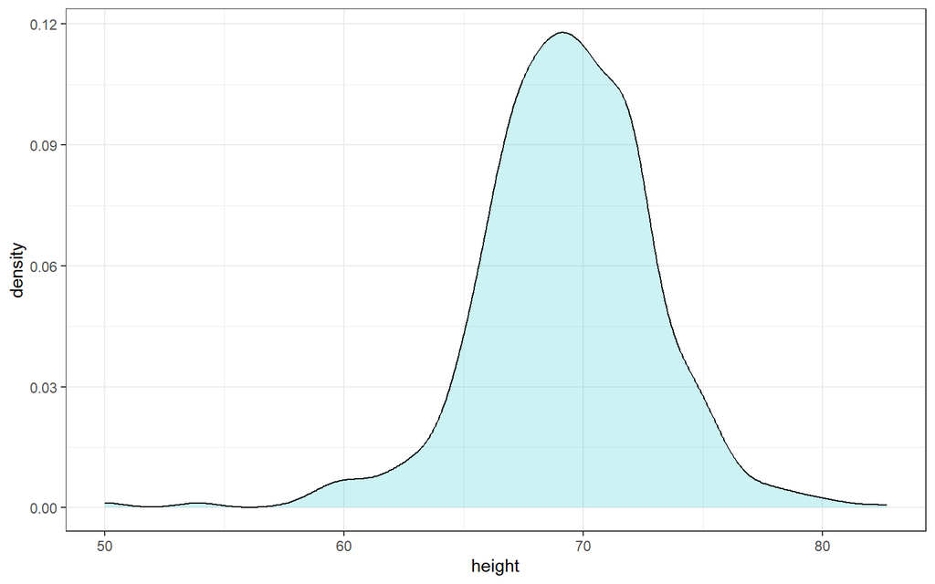

In this plot, we no longer have sharp edges at the interval boundaries and many of the local peaks have been removed. Also, the scale of the y-axis changed from counts to *density*.

To understand the smooth densities, we have to understand *estimates*, a topic we don’t cover until later. However, we provide a heuristic explanation to help you understand the basics so you can use this useful data visualization tool.

The main new concept you must understand is that we assume that our list of observed values is a subset of a much larger list of unobserved values. In the case of heights, you can imagine that our list of 812 male students comes from a hypothetical list containing all the heights of all the male students in all the world measured very precisely. Let’s say there are 1,000,000 of these measurements. This list of values has a distribution, like any list of values, and this larger distribution is really what we want to report to ET since it is much more general. Unfortunately, we don’t get to see it.

However, we make an assumption that helps us perhaps approximate it. If we had 1,000,000 values, measured very precisely, we could make a histogram with very, very small bins. The assumption is that if we show this, the height of consecutive bins will be similar. This is what we mean by smooth: we don’t have big jumps in the heights of consecutive bins. Below we have a hypothetical histogram with bins of size 1:

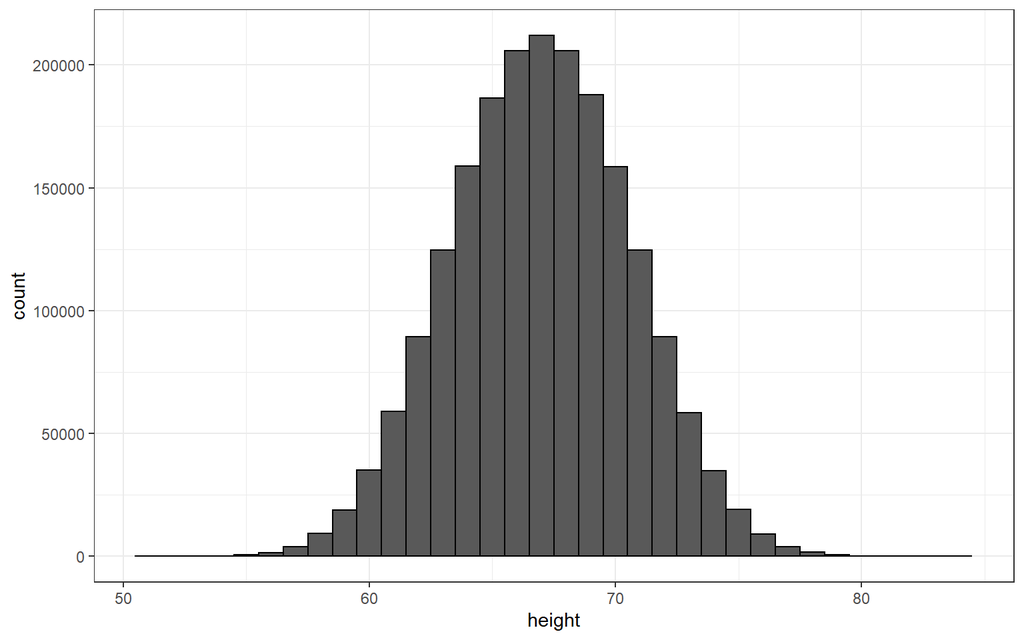

The smaller we make the bins, the smoother the histogram gets. Here are the histograms with bin width of 1, 0.5, and 0.1:

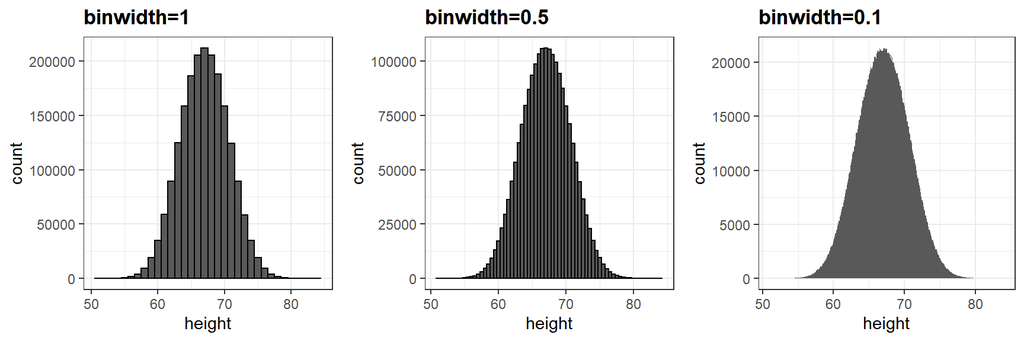

The smooth density is basically the curve that goes through the top of the histogram bars when the bins are very, very small. To make the curve not depend on the hypothetical size of the hypothetical list, we compute the curve on frequencies rather than counts:

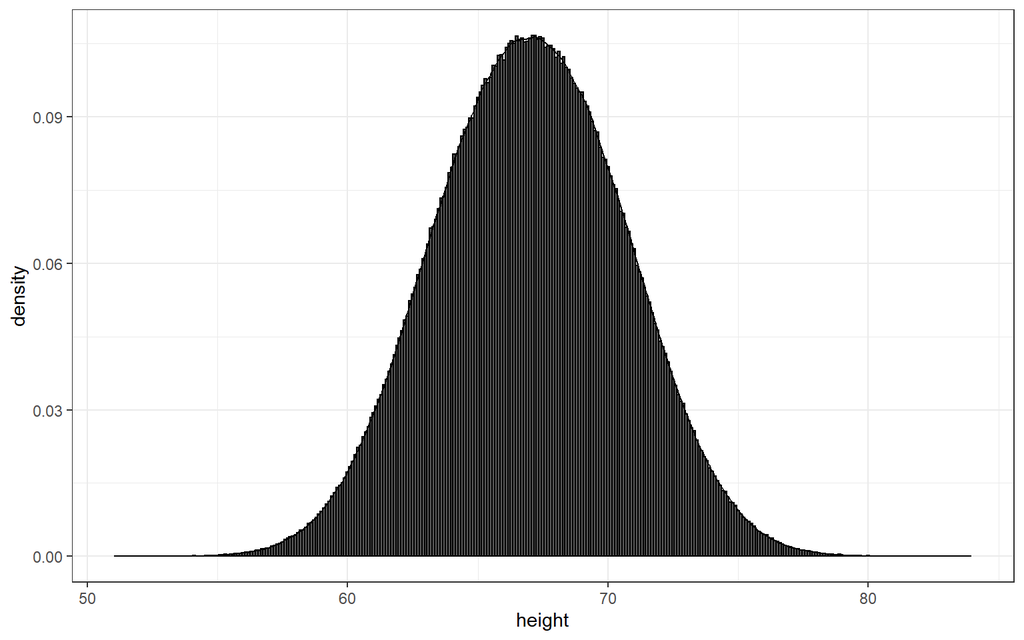

Now, back to reality. We don’t have millions of measurements. Instead, we have 812 and we can’t make a histogram with very small bins.

We therefore make a histogram, using bin sizes appropriate for our data and computing frequencies rather than counts, and we draw a smooth curve that goes through the tops of the histogram bars. The following plots demonstrate the steps that lead to a smooth density:

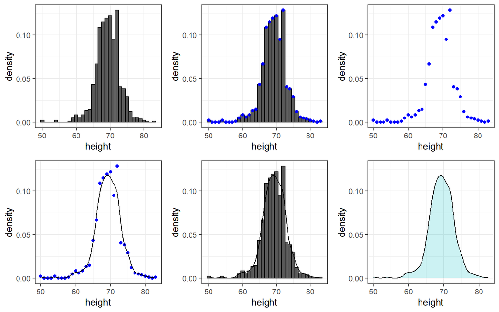

However, remember that *smooth* is a relative term. We can actually control the *smoothness* of the curve that defines the smooth density through an option in the function that computes the smooth density curve. Here are two examples using different degrees of smoothness on the same histogram:

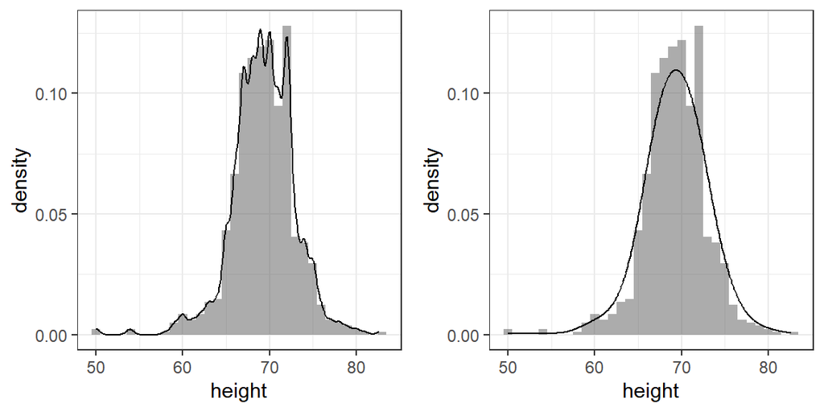

We need to make this choice with care as the resulting visualizations can change our interpretation of the data. We should select a degree of smoothness that we can defend as being representative of the underlying data. In the case of height, we really do have reason to believe that the proportion of people with similar heights should be the same. For example, the proportion that is 72 inches should be more similar to the proportion that is 71 than to the proportion that is 78 or 65. This implies that the curve should be pretty smooth; that is, the curve should look more like the example on the right than on the left.

While the histogram is an assumption-free summary, the smoothed density is based on some assumptions.

### 5.6.1 Interpreting the y-axis

Note that interpreting the y-axis of a smooth density plot is not straightforward. It is scaled so that the area under the density curve adds up to 1. If you imagine we form a bin with a base 1 unit in length, the y-axis value tells us the proportion of values in that bin. However, this is only true for bins of size 1. For other size intervals, the best way to determine the proportion of data in that interval is by computing the proportion of the total area contained in that interval. For example, here are the proportion of values between 65 and 68:

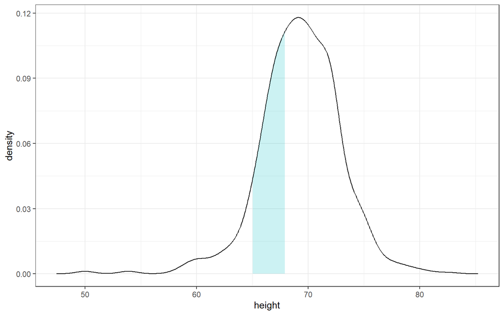

The proportion of this area is about 0.3, meaning that about that proportion is between 65 and 68 inches.

By understanding this, we are ready to use the smooth density as a summary. For this dataset, we would feel quite comfortable with the smoothness assumption, and therefore with sharing this aesthetically pleasing figure with ET, which he could use to understand our male heights data:

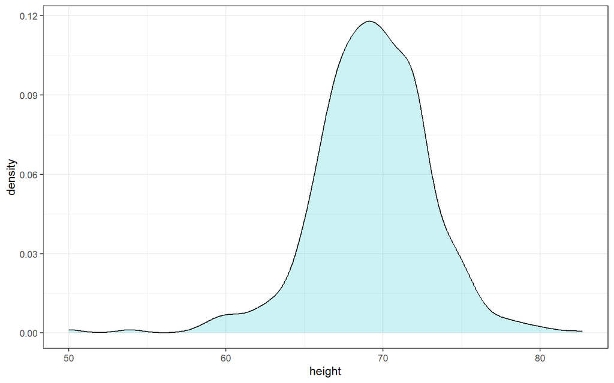

### 5.6.2 Densities permit stratification

As a final note, we point out that an advantage of smooth densities over histograms for visualization purposes is that densities make it easier to compare two distributions. This is in large part because the jagged edges of the histogram add clutter. Here is an example comparing male and female heights:

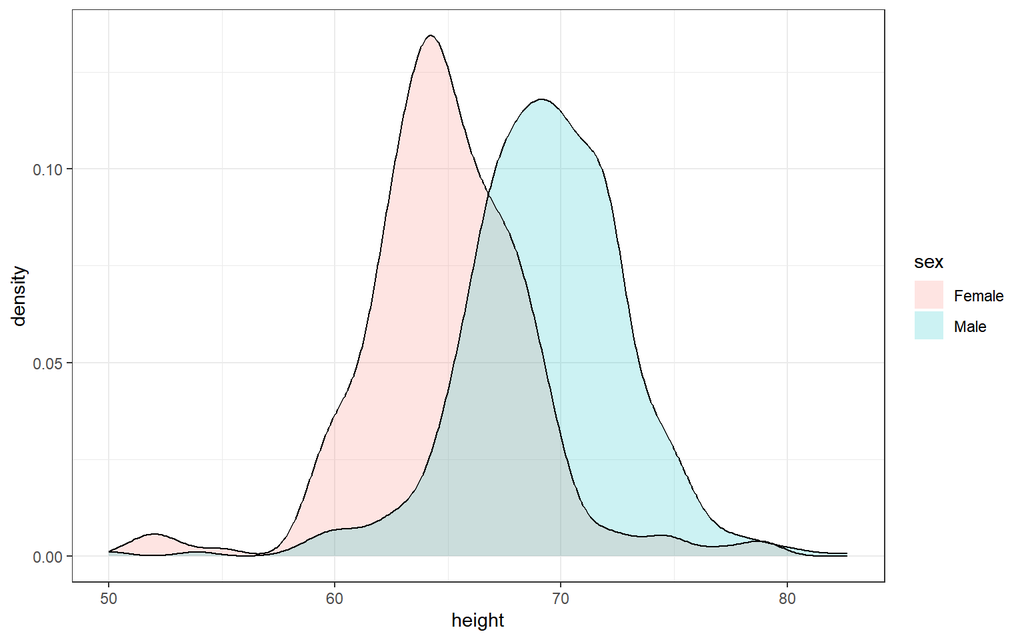

With the right argument, `ggplot` automatically shades the intersecting region with a different color. We will show examples of **ggplot2** code for densities in Section @ref(gapminder) as well as Section @ref(other-geometries).